# Computer Vision Project 2

**Author:** AJ Heskett **Date:** 2025-10-22

# Project_2_581

# Question 1

[figure not shown]

## Question 1.2

[figure not shown]

## Question 1.3

Homography is the mechanism that transforms the object from 1 frame to the other. It is the scalar to multiply the normal coordinates through to get the tranformed coordnates, it effectively reverses the camera's perspective effects. Without homography acting as a filter for the image perspective, the translations would not be possible.

# Question 2

## Panorama views

### Panoramic inputs

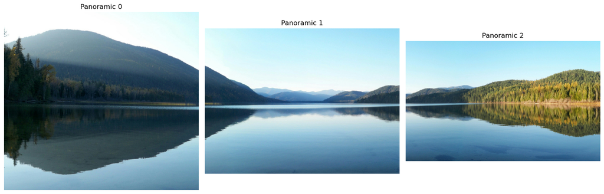

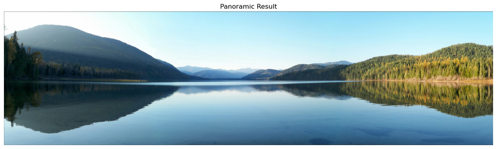

## My Idea, struggles, and successes

The general idea is to take the images, find the homography of the areas that are the same, then warping the images to overlay correctly. One of the main challenges I faced was warping images simultaneously. Since I wanted a system that did not need uniform image sizes, warping was not necessarily straightforward. What I did was create a panoramic that is the size of the images, and then adding the first image in followed by a warped second image that overlays the matched region. It does this recursively allowing for frames to be placed in it. This worked well, and I was able to get an accurate panoramic image. The equation I used for the creation of the output image: $$ W_p = W_a + (W_b - W_o), $$ Where $W_p$ is the width of the panoramic ouput, $W_a$ is the width of image A, $W_b$ is the widht of image b and $W_o$ is the width of the overlapping zone between the images.

# Question 3

## Triangular Mesh Warping

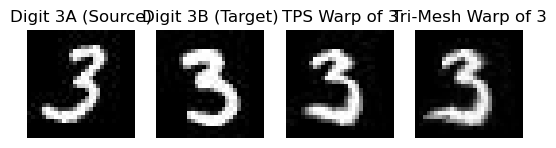

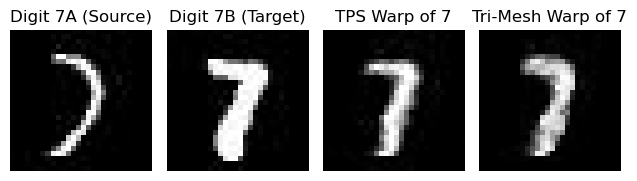

[figure not shown]

## Discussion and Results

The triangle warp seems to be much more consistent, and is better at capturing the numbers. It is also effective at warping the face, with improved key points probably helping make it more seamless. The TPS warp seems to twist the images almost, I believe this is because I am giving both it and the triangle warped image the same points. Without a boundary this will cause the TPS warp will bulge because of the concentration of points in the center. To fix the TPS I added points in all four corners, as shown in the results of the digit numbers. I wanted ot leave the faces because it shows how the quality of coordinates matters, and how certain aspects can change the warps usefulness.